# auvray_marcantoine_projetR

AUVRAY Marc-Antoine

# Projet - Explication du prix du gazole

Ce projet a pour objectifs de :

-Créer un data.frame à partir du fichier PrixCarburants_quotidien_20221215.xml et l’enrichir avec des données externes;

-Essayer, à l’aide de méthodes statistiques et de visualisations pertinentes, d’expliquer le prix du gazole par les différentes variables à votre disposition.

Je l’ai découpé en plusieurs parties, chacune représentées par un onglet de ce projet shiny :

-Partie 1 : Présentation du projet, du code et des données;

-Partie 2 : Analyse unidimensionnelle de chaque variable;

-Partie 3 : Analyse bidimensionnelle;

-Partie 4 : Cartographie;

-Partie 5 : Régression linéaire

## Partie 1 : Présentation du projet, du code et des données :

### Code du fichier auvray_marcantoine_projet_R.Rmd :

Ce script a pour objectif de créer le data.frame souhaité d’après les données du fichier XML et de le stocker dans un fichier dataframe.rds.

```r
# rm(list=ls())
```

Permet de charger le package XML qui sert à importer des données d’un fichier XML :

```r
library(XML)
```

Met dans l’objet string “chemin” le chemin actuel :

```r
chemin = getwd()
chemin
```

```
## [1] "C:/Users/mauvray/Downloads/r/projet_R/projet"
```

Met dans l’objet “carburants” le contenu du fichier XML selon son chemin :

```r
carburants = xmlParse(paste0(chemin, "/", "PrixCarburants_quotidien_20221215.xml"))
```

Met dans l’objet “df” un dataframe initialisé vide avec 0 colonne et un nombre de lignes qui est celui du nombre de stations de gazole dans le XML :

```r
df = data.frame(matrix(nrow=dim(sapply(getNodeSet(carburants,
                                                  "//pdv/prix[@nom='Gazole']/.."),
                                       xmlAttrs))[2],
                       ncol=0))

head(df)
```

```
## tableau de données (data frame) avec 0 colonnes et 6 lignes
```

```r
str(df)
```

```
## 'data.frame':    9326 obs. of  0 variables
```

Rajoute dans “df” les colonnes “id” (identifiant de la station), “latitude”, “longitude”, “cp” (code postal de la station) et “pop” (si c’est une station de route ou d’autoroute) :

```r
df = sapply(c("id", "latitude", "longitude", "cp", "pop"),
            function(str) {df[str] <- sapply(getNodeSet(carburants,
                                                        "//pdv/prix[@nom='Gazole']/.."),
                                             xmlGetAttr,
                                             str)})

head(df)
```

```
##      id        latitude  longitude cp      pop
## [1,] "1000001" "4620100" "519800"  "01000" "R"
## [2,] "1000002" "4621842" "522767"  "01000" "R"
## [3,] "1000004" "4618800" "524500"  "01000" "R"
## [4,] "1000007" "4622100" "524500"  "01000" "R"
## [5,] "1000009" "4619600" "522900"  "01000" "R"
## [6,] "1000012" "4620100" "520000"  "01000" "R"
```

```r
str(df)
```

```
##  chr [1:9326, 1:5] "1000001" "1000002" "1000004" "1000007" "1000009" ...
##  - attr(*, "dimnames")=List of 2
##   ..$ : NULL
##   ..$ : chr [1:5] "id" "latitude" "longitude" "cp" ...
```

Rajoute dans df les colonnes “valeur” (le prix du gazole de la station) , “ville” (de la station) et “dep_num” (le numéro de département de la station).

```r
df = data.frame(cbind(df,
                      valeur=sapply(getNodeSet(carburants,
                                               "/pdv_liste/pdv/prix[@nom='Gazole']"),
                                    xmlGetAttr,
                                    "valeur"),
                      ville=sapply(getNodeSet(carburants,
                                              "//pdv[prix/@nom='Gazole']/ville"),
                                   xmlValue),
                      dep_num = substr(df[,"cp"], 0, 2)))

head(df)
```

```
##        id latitude longitude    cp pop valeur                  ville dep_num
## 1 1000001  4620100    519800 01000   R  1.695 SAINT-DENIS-LÃ¨S-BOURG      01
## 2 1000002  4621842    522767 01000   R  1.719        BOURG-EN-BRESSE      01
## 3 1000004  4618800    524500 01000   R   1.69        Bourg-en-Bresse      01
## 4 1000007  4622100    524500 01000   R  1.683        Bourg-en-Bresse      01
## 5 1000009  4619600    522900 01000   R  1.679        Bourg-en-Bresse      01
## 6 1000012  4620100    520000 01000   R  1.718  SAINT DENIS LES BOURG      01
```

```r
str(df)
```

```
## 'data.frame':    9326 obs. of  8 variables:
##  $ id       : chr  "1000001" "1000002" "1000004" "1000007" ...
##  $ latitude : chr  "4620100" "4621842" "4618800" "4622100" ...
##  $ longitude: chr  "519800" "522767" "524500" "524500" ...
##  $ cp       : chr  "01000" "01000" "01000" "01000" ...
##  $ pop      : chr  "R" "R" "R" "R" ...
##  $ valeur   : chr  "1.695" "1.719" "1.69" "1.683" ...
##  $ ville    : chr  "SAINT-DENIS-LÃ¨S-BOURG" "BOURG-EN-BRESSE" "Bourg-en-Bresse" "Bourg-en-Bresse" ...
##  $ dep_num  : chr  "01" "01" "01" "01" ...
```

Encode la colonne “ville” de “df” au format UTF-8 qui permet de gérer les accents :

```r
Encoding(df$ville) <- "UTF-8"
```

Met au format numérique les colonnes de latitude et longitude de “df” :

```r
df[, "latitude"] = as.numeric(df[, "latitude"])
df[, "longitude"] = as.numeric(df[, "longitude"])
```

Renomme la colonne “valeur” en “prix” et la met au format numérique :

```r
colnames(df)[colnames(df) == "valeur"] = "prix"
df[, "prix"] = as.numeric(df[, "prix"])
```

Renomme la colonne “pop” en “type_voie_1” :

```r
colnames(df)[colnames(df) == "pop"] <- "type_de_voie_1"
```

Dans la colonne “type_voie_1”, renomme les “R” par “route”, les “A” par “autoroute” :

```r
df$type_de_voie_1 <- ifelse(df$type_de_voie_1 == "R",
                            "route",
                            ifelse(df$type_de_voie_1 == "A",
                                   "autoroute",
                                   df$type_de_voie_1))
table(df$type_de_voie_1)
```

```
##
## autoroute     route
##       433      8893
```

Fonction qui prend arguments un dataframe nommé “df”, un entier nommé “nombre_categorie” et un string “nom_colonne_catégorie” (par défaut ““).

Elle retourne le dataframe avec en plus une colonne des quantiles du prix de l’ordre mis dans “nombre_categories”.

(Exemple : avec en “nombre_categorie” 4 et pas de “nom_colonne_categories” renseigné, la fonction renvoie le dataframe avec une nouvelle colonne nommée “quantile_dordre_4” avec 4 valeurs possibles (1,2,3,4) chacune représentant le quartile dans lequel est le prix de la station respective.) :

```r
ajouter_colonnes_quantile <- function(df, nombre_categories, nom_colonne_categories="") {
  if(nom_colonne_categories==""){
    nom_colonne_categories = paste0("quantile_dordre_", as.character(nombre_categories))
  }
  df[[nom_colonne_categories]] = cut(df$prix,
                                     breaks=quantile(df$prix,
                                                     probs=seq(0, 1, 1/nombre_categories)),
                                     labels=1:nombre_categories,
                                     include.lowest=TRUE)
  df[[nom_colonne_categories]] = as.numeric(df[[nom_colonne_categories]])

  return(df)
}
```

Met dans “liste_quantiles”, une liste de 2 éléments : “nombres” un vecteur avec 2,4,10 et “noms_colonne_categories” avec “mediane_numeros_categories”,“quartile_numeros_categories”, “decile_numeros_categories”.

```r
liste_quantiles = list(nombres = c(2,4,10),
                       noms_colonne_categories = c("mediane_numeros_categories","quartile_numeros_categories", "decile_numeros_categories"))
str(liste_quantiles)
```

```
## List of 2
##  $ nombres                : num [1:3] 2 4 10
##  $ noms_colonne_categories: chr [1:3] "mediane_numeros_categories" "quartile_numeros_categories" "decile_numeros_categories"
```

Ajoute dans df 3 colonnes des quantiles des prix d’ordre 2 (médiane), d’ordre 4 (quartiles) et d’ordre 10 (déciles) :

```r
for (i in 1:length(liste_quantiles$nombres)) {
  df = ajouter_colonnes_quantile(df=df,
                                 nombre_categories=liste_quantiles$nombres[i],
                                 nom_colonne_categories=liste_quantiles$noms_colonne_categories[i])
  print(table(df[liste_quantiles$noms_colonne_categories[i]]))
}
```

```
## mediane_numeros_categories
##    1    2
## 4744 4582
## quartile_numeros_categories
##    1    2    3    4
## 2359 2385 2483 2099
## decile_numeros_categories
##    1    2    3    4    5    6    7    8    9   10
## 1060  843  980  907  954  886  912  946  911  927
```

```r
str(df)
```

```
## 'data.frame':    9326 obs. of  11 variables:
##  $ id                         : chr  "1000001" "1000002" "1000004" "1000007" ...
##  $ latitude                   : num  4620100 4621842 4618800 4622100 4619600 ...
##  $ longitude                  : num  519800 522767 524500 524500 522900 ...
##  $ cp                         : chr  "01000" "01000" "01000" "01000" ...
##  $ type_de_voie_1             : chr  "route" "route" "route" "route" ...
##  $ prix                       : num  1.7 1.72 1.69 1.68 1.68 ...
##  $ ville                      : chr  "SAINT-DENIS-LèS-BOURG" "BOURG-EN-BRESSE" "Bourg-en-Bresse" "Bourg-en-Bresse" ...
##  $ dep_num                    : chr  "01" "01" "01" "01" ...
##  $ mediane_numeros_categories : num  1 1 1 1 1 1 1 1 2 1 ...
##  $ quartile_numeros_categories: num  2 2 2 1 1 2 2 2 3 2 ...
##  $ decile_numeros_categories  : num  3 5 3 2 2 5 3 3 6 4 ...
```

Fonction qui permet de charger les adresses du XML, en les encodant en UTF-8 et en les mettant en minuscule :

```r
charger_adresses<-function(){
  adr = sapply(getNodeSet(carburants,"//pdv[prix/@nom='Gazole']/adresse"), xmlValue)
  Encoding(adr) <- "UTF-8"
  adr = tolower(adr)
  return(adr)
}

head(charger_adresses())
```

```
## [1] "596 avenue de trevoux"      "16 avenue de marboz"
## [3] "20 avenue du maréchal juin" "avenue francois pignier"
## [5] "56 rue du stand"            "642 avenue de trevoux"
```

Mets dans liste_remplacements une liste composée de listes :

-liste “plusieurs_choix_avec_espace” : une liste de 2 listes : liste de strings “mot_remplacement” avec les mots (qui ont un espace) qui remplaceront les adresses qui possede au moins un des mots présents respectivement dans les vecteurs de la 2e liste “mots_a_remplacer”;

-liste “plusieurs_choix_sans_espace” : une liste de 2 listes : liste de strings “mot_remplacement” avec les mots (qui n ont pas d espace) qui remplaceront les adresses qui possede au moins un des mots présents respectivement dans les vecteurs de la 2e liste “mots_a_remplacer”;

-liste “un choix” : une liste de strings avec les mots (qui ont un espace) qui remplaceront les adresses qui possedent ce mot;

-liste “regroupements” : une liste de 2 listes : liste de strings “mot_remplacement” avec les mots qui remplaceront les adresses qui possede au moins un des mots présents respectivement dans les vecteurs de la 2e liste “mots_a_remplacer”;

```r
liste_remplacements = list("plusieurs_choix_avec_espace"=list("mot_remplacement"=list("zoneartisanale",
                                                                                      "centrecommercial",
                                                                                      "zoneindustrielle", "lieudit",
                                                                                      "rondpoint", "routenationale",
                                                                                      "voiecommunale","zonecommerciale",
                                                                                      "zoneactivite"),
                                                              "mots_a_remplacer"=list(c("zone artisanale"),
                                                                                      c("centre commercial","c. c.","c cial", "ctre commercial", "c.commercial"),
                                                                                      c("zone industrielle"), c("lieu dit", "lieu-dit"),
                                                                                      c("rond point", "rond-point"), c("route nationale", "rn"),
                                                                                      c("voie communale"),c("zone commerciale","z.c.", "zc"),
                                                                                      c("zone activité", "zone d'activités", "zone activite"))),

                           "plusieurs_choix_sans_espace"=list("mot_remplacement"=list("za","centrecommercial", "zoneindustrielle",
                                                                                      "allee", "lieudit",
                                                                                      "rondpoint", "route", "chaussee",
                                                                                      "residence", "charriere",
                                                                                      "aeroport", "parc", "voie",
                                                                                      "avenue",  "routenationale",
                                                                                      "boulevard"),
                                                              "mots_a_remplacer"=list(c("z.a", "za"), c("c.c", "c/c", "ccial"), c("zi", "z.i", "z.i."),
                                                                                      c("allee", "allées", "allée"), c("lieudit", "lieu-dit"),
                                                                                      c("rondpoint", "rond-point"), c("rte", "route"), c("chaussée", "chaussee"),
                                                                                      c("residence", "résidence"),  c("charrière", "charriere"),
                                                                                      c("aéroport", "aeroport"), c("parcs", "parc"), c("voie"),
                                                                                      c("av.", "av", "ave", "avenue","av.de"), c("rn"),
                                                                                      c("boulevard", "bld", "bvd", "bd", "bd.du", "bld."))),

                           "un_choix"=list("faubourg", "chemin", "lotissement", "quartier", "autoroute", "rue", "aire", "cours",
                                           "pont", "place", "impasse", "promenade",  "hameau", "carrefour", "station", "zac","village",
                                           "domaine", "passage", "plaine", "quai", "plan", "gare", "relais"),

                           "regroupements"=list("mot_remplacement"=list("route",
                                                                        "routenationale_autoroute",
                                                                        "avenue",
                                                                        "boulevard",
                                                                        "rue",
                                                                        "allee_chemin_voie_impasse_carrefour_chaussee_passage_voie_communale",
                                                                        "cours_faubourg_lieudit_village_hameau_promenade_domaine_charriere_plain_plan",
                                                                        "quartier_place_aire_parc_pont_quai_residence_gare_lotissement_rondpoint",
                                                                        "centre_commercial_za_zone_industrielle_zone_commerciale_zone_activite_zac_station_zone_artisanale_relais_aeroport"),

                                                "mots_a_remplacer"=list(c("route"),
                                                                        c("routenationale","autoroute"),
                                                                        c("avenue"),
                                                                        c("boulevard"),
                                                                        c("rue"),
                                                                        c("allee","chemin","voie","impasse", "carrefour", "chaussee", "passage", "voiecommunale"),
                                                                        c("cours","faubourg","lieudit","village", "hameau","promenade", "domaine","charriere","plaine","plan"),
                                                                        c("quartier","place","aire","parc","pont","quai", "residence", "gare", "lotissement", "rondpoint"),
                                                                        c("centrecommercial","za","zoneindustrielle","zonecommerciale", "zoneactivite", "zac",
                                                                          "station", "zoneartisanale","relais", "aeroport"))))
```

La fonction prend en arguments un vecteur “vecteur_adresses” et une liste “liste_remplacements”. Elle retourne une liste de 2 vecteurs. Le premier “type_voie_2_precis” represente le type de voie précis de la station et devient “autre” s il est peu présent dans les données. Le deuxième représente des regroupements des types proches :

```r
vecteurs_types_voie<-function(vecteur_adresses, liste_remplacements){

  for(adresse_i in seq_along(vecteur_adresses)){

    for (vecteur_i in seq_along(liste_remplacements$plusieurs_choix_sans_espace$mots_a_remplacer)) {
      if(grepl(paste(liste_remplacements$plusieurs_choix_sans_espace$mots_a_remplacer[[vecteur_i]], collapse="|"), vecteur_adresses[adresse_i][[1]])){
        vecteur_adresses[adresse_i] = liste_remplacements$plusieurs_choix_sans_espace$mot_remplacement[[vecteur_i]]
      }
    }

    for (vecteur_i in seq_along(liste_remplacements$plusieurs_choix_avec_espace$mots_a_remplacer)) {
      if(any(strsplit(vecteur_adresses[adresse_i], " ")[[1]] %in% liste_remplacements$plusieurs_choix_avec_espace$mots_a_remplacer[[vecteur_i]])){
        vecteur_adresses[adresse_i] = liste_remplacements$plusieurs_choix_avec_espace$mot_remplacement[[vecteur_i]]
      }
    }

    for (mot_i in seq_along(liste_remplacements$un_choix)) {
      if(grepl(liste_remplacements$un_choix[[mot_i]], vecteur_adresses[adresse_i]))
      {
        vecteur_adresses[adresse_i] = liste_remplacements$un_choix[[mot_i]]
      }
    }

  }
  remplacements = union(unlist(liste_remplacements$plusieurs_choix_sans_espace$mot_remplacement),
                        union(unlist(liste_remplacements$plusieurs_choix_avec_espace$mot_remplacement),
                              unlist(liste_remplacements$un_choix)))

  type_voie_2_precis = ifelse(vecteur_adresses %in% remplacements, vecteur_adresses, "autre")

  type_voie_2_cat = type_voie_2_precis
  for(adresse_i in seq_along(type_voie_2_cat)){
    for (vecteur_i in seq_along(liste_remplacements$regroupements$mots_a_remplacer)) {
      if(any(strsplit(type_voie_2_cat[adresse_i], " ")[[1]] %in% liste_remplacements$regroupements$mots_a_remplacer[[vecteur_i]])){
        type_voie_2_cat[adresse_i] = liste_remplacements$regroupements$mot_remplacement[[vecteur_i]]
      }
    }
  }

  return(list("type_voie_2_precis"=type_voie_2_precis,
              "type_voie_2_cat"=type_voie_2_cat))
}
```

Met dans “types_voies” la sortie de cette fontion avec nos données et des adresses issues de la fonction “charger_adresses” :

```r
types_voies = vecteurs_types_voie(vecteur_adresses=charger_adresses(), liste_remplacements=liste_remplacements)

table(types_voies$type_voie_2_precis)
```

```
##
##         aeroport             aire            allee            autre
##                6              141               68              680
##           avenue        boulevard        carrefour centrecommercial
##             2072              500                8               49
##        charriere         chaussee           chemin            cours
##                1                9              156               30
##          domaine         faubourg             gare           hameau
##                4               35                5                4
##          impasse          lieudit      lotissement             parc
##               26               87                6               31
##          passage            place           plaine             plan
##                4              117                6                9
##             pont        promenade             quai         quartier
##               23                5               33               56
##           relais        residence        rondpoint            route
##                2                4                9             2120
##   routenationale              rue          station          village
##              415             2038                8                8
##             voie               za  zonecommerciale zoneindustrielle
##               28              407                2              114
```

```r
table(types_voies$type_voie_2_cat)
```

```
##
##                                               allee_chemin_voie_impasse_carrefour_chaussee_passage_voie_communale
##                                                                                                               299
##                                                                                                             autre
##                                                                                                               680
##                                                                                                            avenue
##                                                                                                              2072
##                                                                                                         boulevard
##                                                                                                               500
## centre_commercial_za_zone_industrielle_zone_commerciale_zone_activite_zac_station_zone_artisanale_relais_aeroport
##                                                                                                               588
##                                      cours_faubourg_lieudit_village_hameau_promenade_domaine_charriere_plain_plan
##                                                                                                               189
##                                           quartier_place_aire_parc_pont_quai_residence_gare_lotissement_rondpoint
##                                                                                                               425
##                                                                                                             route
##                                                                                                              2120
##                                                                                          routenationale_autoroute
##                                                                                                               415
##                                                                                                               rue
##                                                                                                              2038
```

Mets 2 colonnes de “df” ces 2 vecteurs :

```r
df = cbind(df, type_voie_2_precis=types_voies$type_voie_2_precis)
df = cbind(df, type_voie_2_cat=types_voies$type_voie_2_cat)
```

Récupère les services de chaque station et les mets dans le vecteur “vecteur_services” :

```r
vecteur_services = sapply(getNodeSet(carburants, "//pdv/services/service"), xmlValue)

head(vecteur_services)
```

```
## [1] "Station de gonflage"
## [2] "Vente de gaz domestique (Butane, Propane)"
## [3] "DAB (Distributeur automatique de billets)"
## [4] "Vente de gaz domestique (Butane, Propane)"
## [5] "DAB (Distributeur automatique de billets)"
## [6] "Toilettes publiques"
```

Encode ce vecteur pour qu’il gère les accents :

```r
Encoding(vecteur_services) <- "UTF-8"
```

Met dans le vecteur “vecteur_uniques_services” les valeurs uniques du vecteur “vecteur_services” :

```r
vecteur_uniques_services = unique(vecteur_services)

vecteur_uniques_services
```

```
##  [1] "Station de gonflage"
##  [2] "Vente de gaz domestique (Butane, Propane)"
##  [3] "DAB (Distributeur automatique de billets)"
##  [4] "Toilettes publiques"
##  [5] "Relais colis"
##  [6] "Boutique alimentaire"
##  [7] "Boutique non alimentaire"
##  [8] "Vente de fioul domestique"
##  [9] "Carburant additivé"
## [10] "Location de véhicule"
## [11] "Piste poids lourds"
## [12] "Vente d'additifs carburants"
## [13] "Automate CB 24/24"
## [14] "Lavage automatique"
## [15] "Bar"
## [16] "Bornes électriques"
## [17] "Wifi"
## [18] "Laverie"
## [19] "Restauration à emporter"
## [20] "Restauration sur place"
## [21] "Lavage manuel"
## [22] "Services réparation / entretien"
## [23] "Douches"
## [24] "Espace bébé"
## [25] "Aire de camping-cars"
## [26] "Vente de pétrole lampant"
## [27] "GNV"
```

Met dans “df” autant de nouvelles colonnes qu’il y a de service différent, elles sont initialisées avec NA :

```r
df = cbind(df,
           setNames(matrix(nrow=nrow(df),
                           ncol=length(vecteur_uniques_services),
                           dimnames=list(NULL,
                                         vecteur_uniques_services)),
                    0))

str(df)
```

```
## 'data.frame':    9326 obs. of  40 variables:
##  $ id                                       : chr  "1000001" "1000002" "1000004" "1000007" ...
##  $ latitude                                 : num  4620100 4621842 4618800 4622100 4619600 ...
##  $ longitude                                : num  519800 522767 524500 524500 522900 ...
##  $ cp                                       : chr  "01000" "01000" "01000" "01000" ...
##  $ type_de_voie_1                           : chr  "route" "route" "route" "route" ...
##  $ prix                                     : num  1.7 1.72 1.69 1.68 1.68 ...
##  $ ville                                    : chr  "SAINT-DENIS-LèS-BOURG" "BOURG-EN-BRESSE" "Bourg-en-Bresse" "Bourg-en-Bresse" ...
##  $ dep_num                                  : chr  "01" "01" "01" "01" ...
##  $ mediane_numeros_categories               : num  1 1 1 1 1 1 1 1 2 1 ...
##  $ quartile_numeros_categories              : num  2 2 2 1 1 2 2 2 3 2 ...
##  $ decile_numeros_categories                : num  3 5 3 2 2 5 3 3 6 4 ...
##  $ type_voie_2_precis                       : chr  "avenue" "avenue" "avenue" "avenue" ...
##  $ type_voie_2_cat                          : chr  "avenue" "avenue" "avenue" "avenue" ...
##  $ Station de gonflage                      : logi  NA NA NA NA NA NA ...
```

[output cut: 26 more lines]

Met dans une liste de listes “liste_services_by_station” chaque liste de services que propose une station :

```r
liste_services_by_station = lapply(getNodeSet(carburants, "//pdv"),
                                   function(pdv) {
                                     lapply(getNodeSet(pdv, "./services/service"), xmlValue)
})

head(liste_services_by_station[1])
```

```
## [[1]]
## [[1]][[1]]
## [1] "Station de gonflage"
##
## [[1]][[2]]
## [1] "Vente de gaz domestique (Butane, Propane)"
##
## [[1]][[3]]
## [1] "DAB (Distributeur automatique de billets)"
```

Sur chaque ligne entière i de “df”, met dans le vecteur “services_station” la liste des services que propose la i ème station, puis pour chaque numero j de string dans “vecteur_uniques_services”, si la i ème station propose le j ème service, alors elle prend le booléen TRUE dans la colonne respective, sinon FALSE :

```r
for (i in 1:nrow(df)) {
  services_station = liste_services_by_station[[i]]
  for (j in 1:length(vecteur_uniques_services)) {
    if (vecteur_uniques_services[j] %in% services_station) {
      df[i, vecteur_uniques_services[j]] = TRUE
    }
    else{
      df[i, vecteur_uniques_services[j]] = FALSE
    }
  }
}
```

Met dans une colonne “nombre_services” de “df”, le nombre de services que propose chaque station :

```r
for (i in 1:nrow(df)) {
  df[i, "nombre_services"] = length(grep(TRUE, df[i, vecteur_uniques_services]))

}
```

Enregistre le dataframe “df” dans le fichier “dataframe.rds” :

```r
saveRDS(df, "dataframe.rds")
```

Ici les fonctions présentes dans le fichier fonctions.R

```r
source("fonctions.R")
# pour récuperer les colonnes d'un dataframe et les trier en fonction du type
print("tri_colonnes_noms : ")
```

```
## [1] "tri_colonnes_noms : "
```

```r
tri_colonnes_noms
```

```
## function (df, n_levels = 50)
## {
##     booleen = c()
##     numerique_continu = c()
##     numerique_discret = c()
##     caractere_continu = c()
##     caractere_discret = c()
##     for (nom_colonne in colnames(df)) {
##         colonne = df[, nom_colonne]
##         if (is.logical(colonne)) {
##             booleen = c(booleen, nom_colonne)
##         }
##         if (is.character(colonne)) {
##             if (length(unique(colonne)) < n_levels) {
##                 caractere_discret = c(caractere_discret, nom_colonne)
##             }
##             else {
##                 caractere_continu = c(caractere_continu, nom_colonne)
##             }
##         }
##         if (is.numeric(colonne)) {
##             if (length(unique(colonne)) < n_levels) {
##                 numerique_discret = c(numerique_discret, nom_colonne)
##             }
##             else {
##                 numerique_continu = c(numerique_continu, nom_colonne)
##             }
##         }
##     }
##     liste = list(booleen = booleen, numerique_continu = numerique_continu,
##         numerique_discret = numerique_discret, caractere_continu = caractere_continu,
##         caractere_discret = caractere_discret)
##     return(liste)
## }
```

```r
print("load_pop_municip : ")
```

```
## [1] "load_pop_municip : "
```

```r
load_pop_municip
```

```
## function (file = "insee_rp_hist_1968.xlsx", file_codes = "laposte_hexasmal.csv")
## {
##     library("readxl")
##     pop_municip = data.frame(read_excel("insee_rp_hist_1968.xlsx",
##         skip = 4))
##     colnames(pop_municip) = c("codgeo", "nom_ville", "annee",
##         "nombre_habitants")
##     pop_municip$annee = as.numeric(pop_municip$annee)
##     pop_municip$nombre_habitants = as.numeric(pop_municip$nombre_habitants)
##     Encoding(pop_municip$nom_ville) <- "UTF-8"
##     codes_cp_commun = read.csv(file_codes, sep = ";")[, c("Code_commune_INSEE",
##         "Code_postal")]
##     colnames(codes_cp_commun) = c("codgeo", "cp")
##     pop_municip = merge(pop_municip, codes_cp_commun)
##     df_max_year <- aggregate(pop_municip$annee, by = list(pop_municip$cp),
##         max)
##     colnames(df_max_year) = c("cp", "annee")
##     df_merged <- merge(pop_municip, df_max_year)
##     pop_municip = aggregate(pop_municip$nombre_habitants, by = list(pop_municip$cp),
##         max)
##     colnames(pop_municip) = c("cp", "nombre_habitants")
##     return(pop_municip)
## }
```

```r
print("add_pop : ")
```

```
## [1] "add_pop : "
```

```r
add_pop
```

```
## function (df, file = "insee_rp_hist_1968.xlsx", file_codes = "laposte_hexasmal.csv")
## {
##     df_pop_municip = load_pop_municip(file = "insee_rp_hist_1968.xlsx",
##         file_codes = "laposte_hexasmal.csv")[, c("cp", "nombre_habitants")]
##     merge_ = merge(df, df_pop_municip, all.x = TRUE)
##     return(merge_)
## }
```

```r
print("load_rafineries : ")
```

```
## [1] "load_rafineries : "
```

```r
load_rafineries
```

```
## function ()
## {
##     nom = c("Raffinerie de Normandie", "Raffinerie de Donges",
##         "Raffinerie de Port-Jérôme-Gravenchon", "Raffinerie de Lavéra",
##         "Plateforme de la Mède ", "Raffinerie de Feyzin", "Raffinerie de Fos",
##         "Raffinerie de Grandpuits")
##     latitude = c(49.4752211, 47.3135413, 49.4752211, 43.4074,
##         43.39819, 45.6657132, 43.45065, 48.5922882)
##     longitude = c(0.5528246, -2.0651766, 0.5528246, 5.0553, 5.11637,
##         4.8409521, 4.9239384, 2.9486286)
##     df_raffineries = data.frame(nom, latitude, longitude)
##     return(df_raffineries)
## }
```

# Partie 2 : Analyse unidimensionnelle de chaque variable;

Le code de cette partie est dans app.R.

Voici quelques exemples de graphiques disponibles :

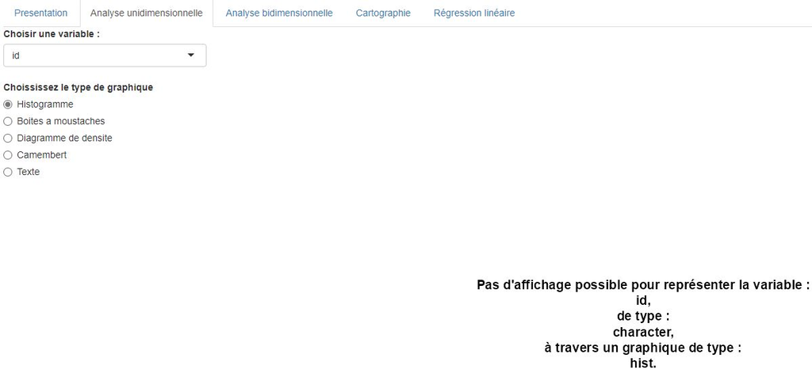

a

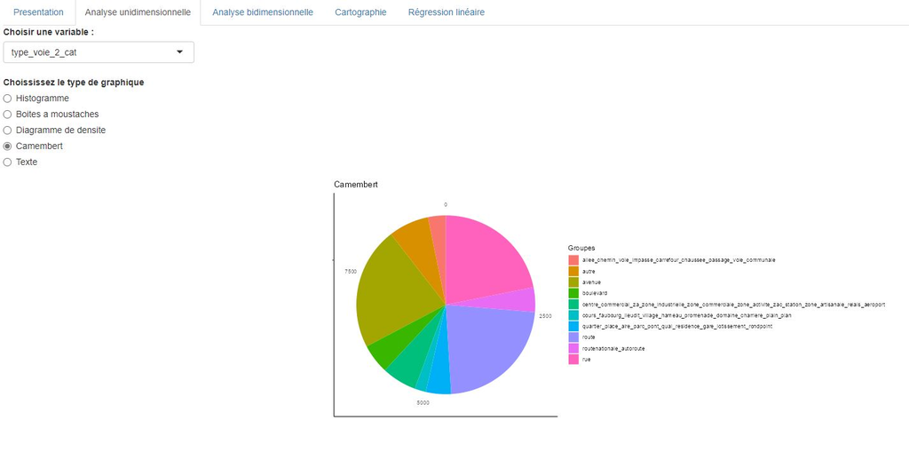

b

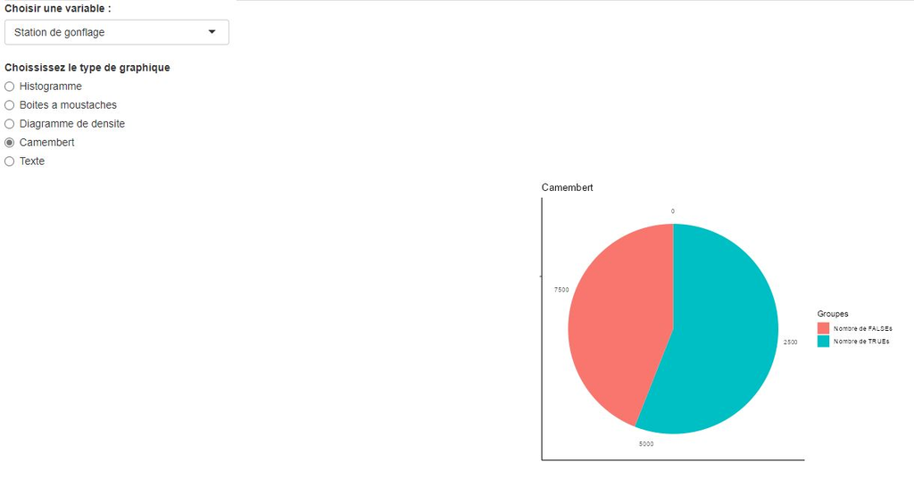

c

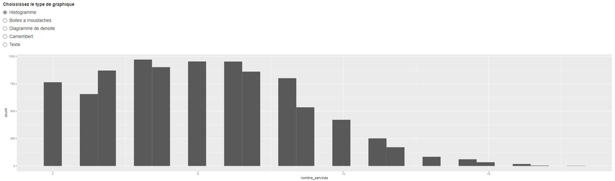

d

# Partie 3 : Analyse bidimensionnelle;

Le code de cette partie est dans app.R.

Voici quelques exemples de graphiques disponibles :

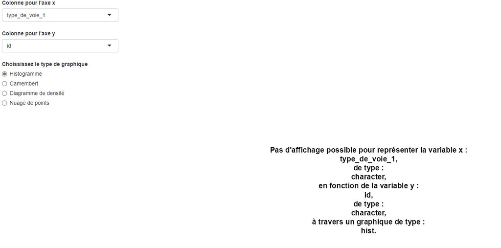

e

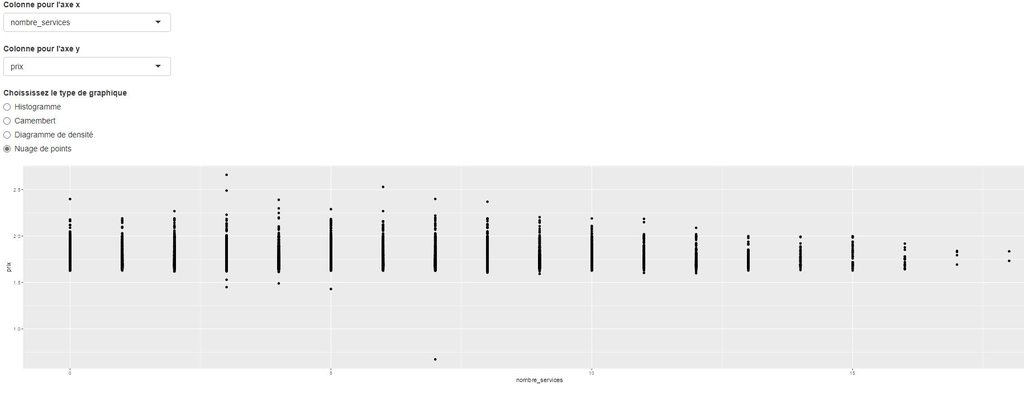

f

```r
library(htmltools)
library(rvest)
# relancer le code du Rmarkown sur les cartes
rmarkdown::render(input = "cartes.Rmd",
                  output_file = sprintf("cartes.html"), quiet = TRUE)
HTML(as.character(read_html("cartes.html")))
```

# cartes.Rmd

## Partie 4 : Cartographie

Charger les dataframes et les fonctions présentes dans fonctions.R :

```r
source("fonctions.R")

df = readRDS("dataframe.rds")
df_pop = readRDS("dataframe_pop.rds")
df_raffineries = load_rafineries()
```

Carte des stations selon le prix de leur gazole (de manière continue) :

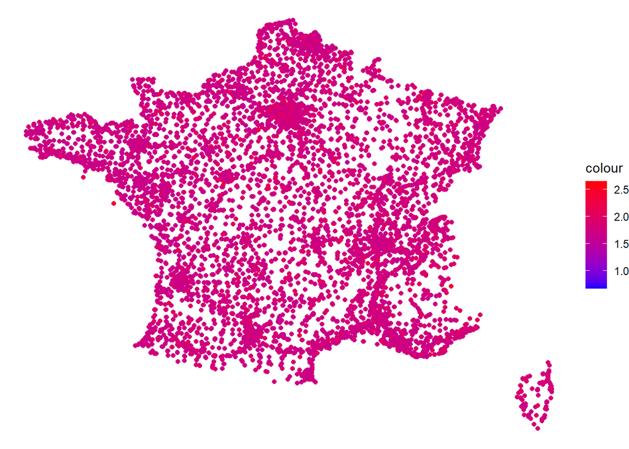

```r
ggplot(df, aes_string(x=df$longitude/100000, y=df$latitude/100000,
                      color=df$prix))+geom_point()+
  theme(panel.grid.major = element_blank(),
        panel.grid.minor = element_blank())+
  theme_void()+
  scale_color_gradient(low = "blue", high = "red")
```

Carte des stations selon le prix de leur gazole (en 2 parties égales) :

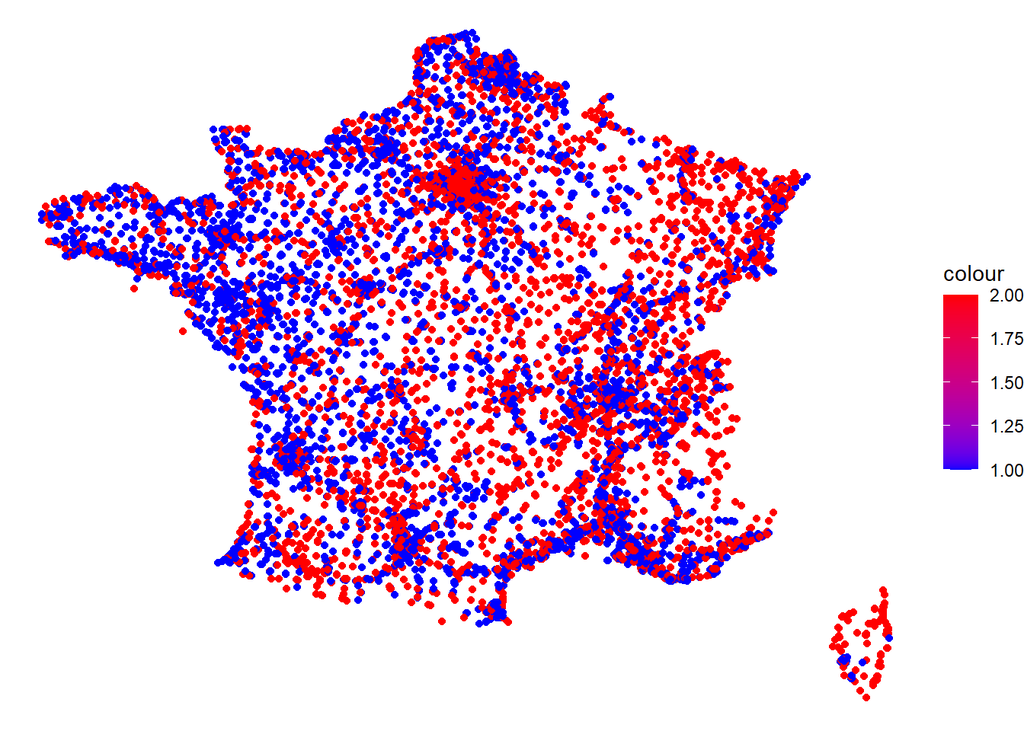

```r
ggplot(df, aes_string(x=df$longitude/100000, y=df$latitude/100000,
                      color=df$mediane_numeros_categories))+geom_point()+
  theme(panel.grid.major = element_blank(),
        panel.grid.minor = element_blank())+
  theme_void()+
  scale_color_gradient(low = "blue", high = "red")
```

Carte des stations selon le prix de leur gazole (en 4 parties égales) :

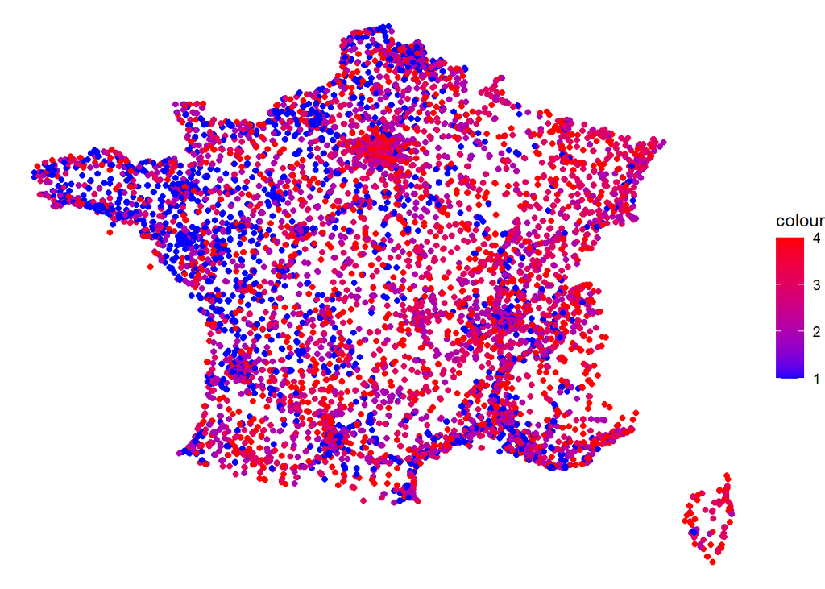

```r
ggplot(df, aes_string(x=df$longitude/100000, y=df$latitude/100000,
                      color=df$quartile_numeros_categories))+geom_point()+
  theme(panel.grid.major = element_blank(),
        panel.grid.minor = element_blank())+
  theme_void()+
  scale_color_gradient(low = "blue", high = "red")
```

Carte des stations selon le prix de leur gazole (en 10 parties égales) :

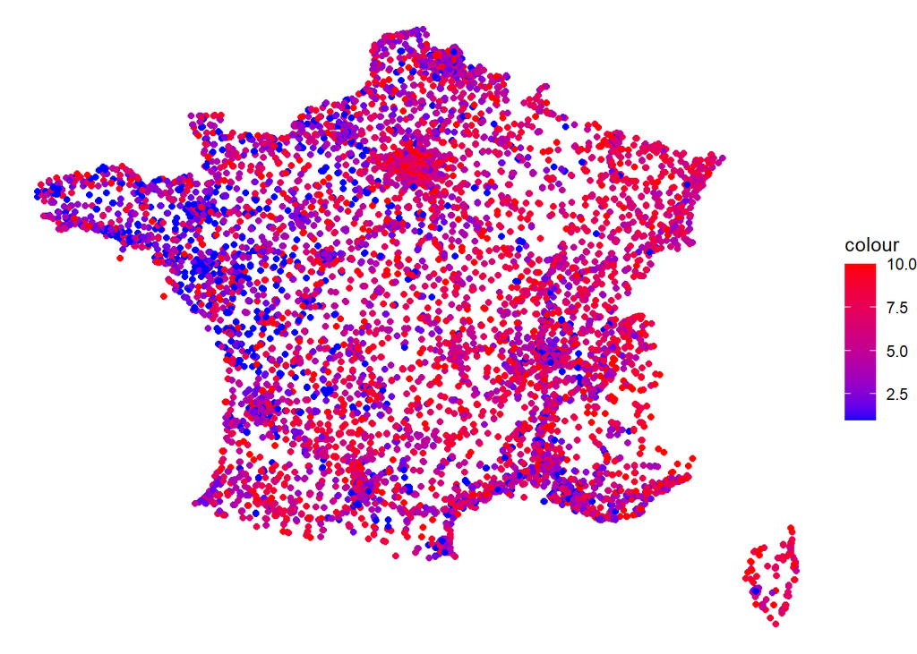

```r
ggplot(df, aes_string(x=df$longitude/100000, y=df$latitude/100000,
                      color=df$decile_numeros_categories))+geom_point()+
  theme(panel.grid.major = element_blank(),
        panel.grid.minor = element_blank())+
  theme_void()+
  scale_color_gradient(low = "blue", high = "red")
```

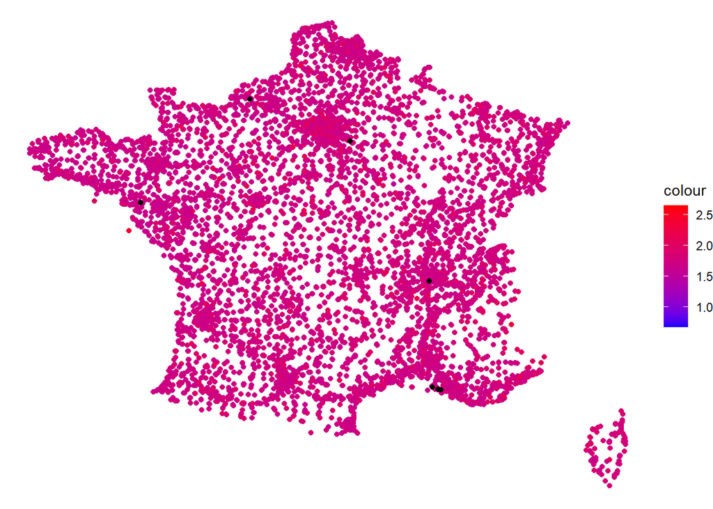

```r
ggplot(df, aes_string(x=df$longitude/100000, y=df$latitude/100000, color=df$prix)) +
  geom_point() +
  scale_color_gradient(low="blue", high="red") +
  geom_point(data=df_raffineries, aes_string(x=df_raffineries$longitude, y=df_raffineries$latitude), color="black") +
  theme(panel.grid.major = element_blank(), panel.grid.minor = element_blank()) +
  theme_void()
```

# Partie 5 : Régression linéaire

```r
# pour séparer un jeu de données
print("split_ : ")
```

```
## [1] "split_ : "
```

```r
split_
```

```
## function (df, nombre_tests)
## {
##     suppressMessages(df_test <- df %>% sample_n(nombre_tests))
##     suppressMessages(df_train <- df %>% anti_join(df_test))
##     return(list(df_train = df_train, df_test = df_test))
## }
```

```r
# pour fitter un modele lineaire sur des données
print("modele_lineaire : ")
```

```
## [1] "modele_lineaire : "
```

```r
modele_lineaire
```

```
## function (df_train, prix = prix)
## {
##     modele_fit <- train(prix ~ ., data = df_train, method = "lm")
##     return(modele_fit)
## }
```

```r
# pour afficher la comparaison entre données
print("table_prediction : ")
```

```
## [1] "table_prediction : "
```

```r
table_prediction
```

```
## function (df, nombre_tests, prix = prix, nom_model)
## {
##     liste_train_test = split_(df = df, nombre_tests = nombre_tests)
##     df_train = liste_train_test$df_train
##     df_test = liste_train_test$df_test
##     if (nom_model == "modele_lineaire") {
##         modele_fit = modele_lineaire(df = df_train, prix = prix)
##     }
##     colnames(df_test)[colnames(df_test) == as.character(substitute(prix))] <- "y_observés"
##     tablo = data.frame(observations_y = df_test$y_observés,
##         predictions_y = predict(modele_fit, df_test))
##     return(tablo)
## }
```

Quelques exemples de sorties possibles :

Le code de cette partie est dans app.R.

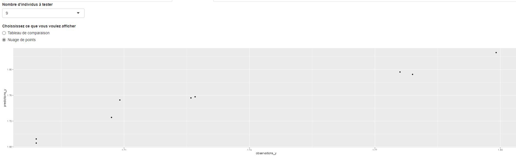

a

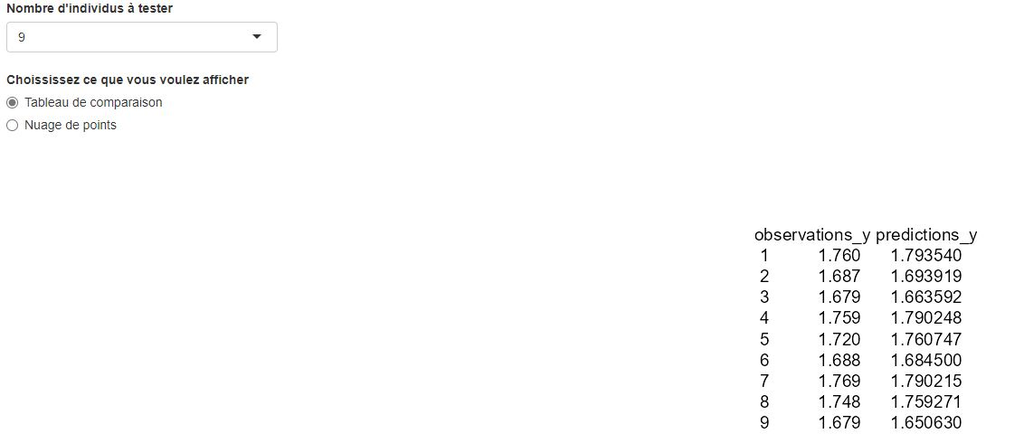

a